# Prosper Loan Data - Visualizations

### 3.12 Time vs Loan Amount vs Income Range

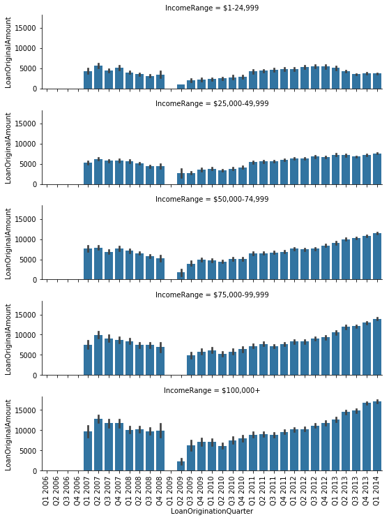

```python
g=sb.FacetGrid(data = loan_df[(loan_df['IncomeRange']=='$1-24,999')|(loan_df['IncomeRange']=='$25,000-49,999')|
                              (loan_df['IncomeRange']=='$50,000-74,999')|
                              (loan_df['IncomeRange']=='$75,000-99,999')|
                              (loan_df['IncomeRange']=='$100,000+')], col = 'IncomeRange', col_wrap = 1, height=2, aspect = 4,
                     col_order = ['$1-24,999',  '$25,000-49,999', '$50,000-74,999',
       '$75,000-99,999', '$100,000+'])
g.map(sb.barplot, 'LoanOriginationQuarter', 'LoanOriginalAmount', order=quarters_order)
plt.xticks(rotation = 90);
```

We can see difference in loan amounts over time that are taken by different income range categories. In general, people with higher income takes higher loans and loan amounts increased after 2009. However, for people with income lower than 25 thousands, the average loan amount decreased in 2013.

### 3.13 Prosper Rating vs Loan Amount vs Income Range

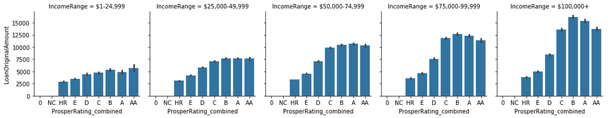

```python
g=sb.FacetGrid(data = loan_df[(loan_df['IncomeRange']=='$1-24,999')|(loan_df['IncomeRange']=='$25,000-49,999')|
                              (loan_df['IncomeRange']=='$50,000-74,999')|
                              (loan_df['IncomeRange']=='$75,000-99,999')|
                              (loan_df['IncomeRange']=='$100,000+')], col = 'IncomeRange', col_wrap = 5, height = 3,
                     col_order = ['$1-24,999',  '$25,000-49,999', '$50,000-74,999',
       '$75,000-99,999', '$100,000+'])
g.map(sb.barplot, 'ProsperRating_combined', 'LoanOriginalAmount', order=ProsperRating_order);
```

We see under each income range category small difference in loan amounts under HR-D rated users, and big difference in loans for C-AA users.

### 3.14 Loan Original Amount vs Monthly Loan Payment vs Borrow Rate

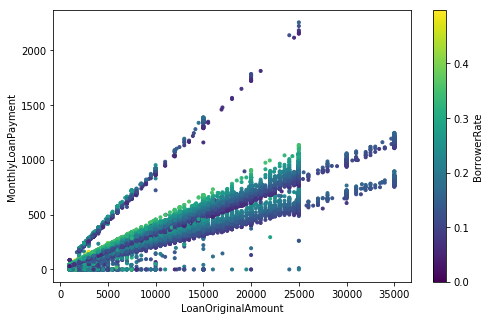

```python
# YOUR CODE HERE
plt.figure(figsize = [8,5])
plt.scatter(data = loan_df,  x = 'LoanOriginalAmount', y = 'MonthlyLoanPayment',c='BorrowerRate', marker='.')
plt.colorbar(label = 'BorrowerRate')
#plt.xlim(0,160)
plt.xlabel('LoanOriginalAmount')
plt.ylabel('MonthlyLoanPayment');
```

Seems that there is correlation between Monthly Loan Payment and Borrower rate. However, it looks like it depends on which 'line' it is located.

### 3.15 Loan Original Amount vs Monthly Loan Payment vs Payment Term

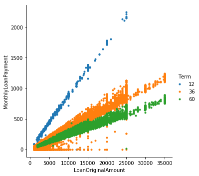

```python
plt.figure(figsize = [8,5])
g = sb.FacetGrid(data = loan_df, hue = 'Term', height = 5)
g.map(plt.scatter, 'LoanOriginalAmount', 'MonthlyLoanPayment', marker='.')
g.add_legend();
```

We can see three separate 'lines' for different loan duration.

### Talk about some of the relationships you observed in this part of the investigation. Were there features that strengthened each other in terms of looking at your feature(s) of interest?

It was interesting to see different patterns of Borrower Rate for different loan duration over the years and to understand how choice between different loan durations are made (higher loans for longer periods).

### Were there any interesting or surprising interactions between features?

We saw clear difference in relation between Loan Amount and Monthly Payment with regards to different loan durations.